# Effects of GDP on Access to Renewable Energy

### Sarah Grace Burns

#### 17 Feb. 2026

## Introduction

Access to electricity provides many benefits that are crucial for developing countries to grow and advance. Electricity is a form of healthcare, keeping food refrigerated and safe, making healthy food more available, refrigerating vaccines and other medicines, and providing necessary light and technologies for life-saving operations and procedures. Electricity improves safety by lighting up streets and houses. It improves education by making it possible to study after dark, opens access to global knowledge and communication through the internet, and creates learning environments where students can reliably engage with modern tools and resources. Clean green energy, in particular, can replace other forms of polluting energy, improving air quality on a local and global scale. Clean energy can also provide energy to homes without being reliant on a centralized grid or infrastructure that is often lacking in developing countries.

Today, developed high-GDP countries are beginning to make the transition to clean energy. While this transition is vital, many developing countries lack access to reliable energy as a whole. Expanding access to clean energy in low-GDP countries presents a **rare dual opportunity**: to accelerate the global move toward sustainability while also providing a critical foundation for socioeconomic development, economic growth, and improved quality of life.

Focusing on improving access to clean energy in developing nations relates to multiple Sustainable Development goals.

### Sustainable Development

Sustainable Development **goal number 7 is to “ensure access to affordable, sustainable modern energy.”**

In the context of this goal, we should focus our efforts on helping low-GDP countries gain access to energy.

This project also relates to:

- #3: Good Health and Well-being
- #4: Quality Education
- #9: Industry, Innovation and Infrastructure
- #10: Reduced Inequalities
- #11: Sustainable Cities and Communities
- #12: Responsible Consumption and Production

### Introduction of Datasets

We will use four data sets

1. Gapminder from *Gapminder*
2. A Carbon Emission Dataset from *The Global Carbon Project*
3. A Renewable Energy Dataset from *IRINA*
4. A Levelized Cost of Energy Dataset from *Our World in Data*

#### Gapminder Dataset

[Gapminder](https://www.gapminder.org/) is a Swedish foundation that pools multiple sources of data into large, informative datasets. By diversely sourcing data, they are able to “fill in gaps” and create data sets that stretch over many years and topics. This particular Gapminder dataset includes information on life expectancy, population, and GDP/capita for countries between 1952 and 2007.

#### Carbon Emission Dataset

[The Global Carbon Project](https://www.globalcarbonproject.org/) (GCP) is a common source of data for the international science community. The data is primarily focused on anthropogenic climate change and is used to formulate climate policy and action across the globe. The data highlights the rising concentrations of the three greenhouse gases, carbon dioxide (CO2), methane (CH4), and nitrous oxide (N2O). The GCP was founded in 2001 and has since acted as a collaborative space to promote coordinated research and sustainability. This particular GCP dataset provides information on carbon emissions and nonrenewable energy use in different countries from 1750 to 2023.

#### Renewable Energy Dataset

[The International Renewable Energy Agency](https://www.irena.org/) (IRENA) helps countries transition from fossil fuels to renewable forms of energy. IRINA analyses and collects data on renewable energy technologies, policies, finances, and investments across the globe. This information helps IRINA advise countries and corporations in order to accelerate the transition to renewable energy worldwide. This particular dataset shows what types and how much renewable energy countries are using. The data runs from 2000 through 2024.

#### Levelized Cost of Energy Dataset

The levelized cost of energy dataset is published on [Our World In Data](https://ourworldindata.org/grapher/levelized-cost-of-energy). Our World In Data publishes data on pretty much anything you can think of. Their aim is to make data available and comprehensible to everyone so we can better understand what is happening in the world, and hopefully, work to make the world a better place. This dataset, in particular, shows the average cost of energy as adjusted for inflation.

## Defining Low and High GDP Countries

The gross domestic product (GDP) refers to the total production occurring within the geographic boundaries of a country in one year. While this is only one aspect of a country’s economic development, we often use it to understand and compare the wealth of countries. Here we will use it to separate wealthy countries from poor, developing countries.

## Countries with the Lowest GDP

#### This Table shows the countries with the lowest GDP average from 1750 to 2023.

| country | Average GDP |
| --- | --- |
| Barbados | 2647899383 |
| Burundi | 4563367871 |
| Cape Verde | 1256773149 |
| Central African Republic | 3044725804 |
| Comoros | 562643736 |
| Djibouti | 1239459663 |
| Dominica | 299898006 |
| Eswatini | 3500084113 |
| Gambia | 1578548711 |
| Guinea-Bissau | 1290914888 |
| Iceland | 6985627220 |
| Lesotho | 2665199943 |
| Liberia | 4365905188 |
| Mauritania | 4689983736 |
| Montenegro | 4607015959 |
| Saint Lucia | 747343401 |
| Sao Tome and Principe | 310779720 |
| Seychelles | 876666453 |
| Sierra Leone | 5444549064 |
| Togo | 5013861739 |

## Countries with the Highest GDP

#### This Table shows the countries with the highest GDP average from 1750 to 2023.

| country | Average GDP |
| --- | --- |
| Brazil | 6.478676e+11 |
| Canada | 4.080397e+11 |
| China | 4.993999e+12 |
| Egypt | 3.684184e+11 |
| France | 6.358313e+11 |
| Germany | 8.828772e+11 |
| India | 1.509518e+12 |
| Indonesia | 4.663417e+11 |
| Iran | 5.219096e+11 |
| Italy | 6.222759e+11 |
| Japan | 1.549049e+12 |
| Mexico | 5.090746e+11 |
| Russia | 1.766936e+12 |
| Saudi Arabia | 4.680993e+11 |
| South Korea | 4.689859e+11 |
| Spain | 3.174452e+11 |
| Turkey | 4.653790e+11 |
| United Kingdom | 6.885099e+11 |
| United States | 3.712646e+12 |
| World | 5.888356e+13 |

Before we determine the use of clean energy, let’s first look at the amount of energy overall that is used by low vs high GDP countries.

## Total Energy Consumption in the 20 Lowest GDP Countries and 20 Highest GDP Countries

#### This graph shows each countries total energy consumption (renewable and nonrenewable energies).

[interactive chart not shown]

As we can see, High-GDP countries are using significantly more energy than low-GDP countries. Here we can already see a discrepancy between energy accessibility.

# Does the GDP of a country influence what percentage of its energy sources are renewable?

## Proportion of Renewable Energy Between Low and High-GDP Countries

#### This graph shows the proportion of total energy consumption composed of renewable energy between low- and high-GDP countries.

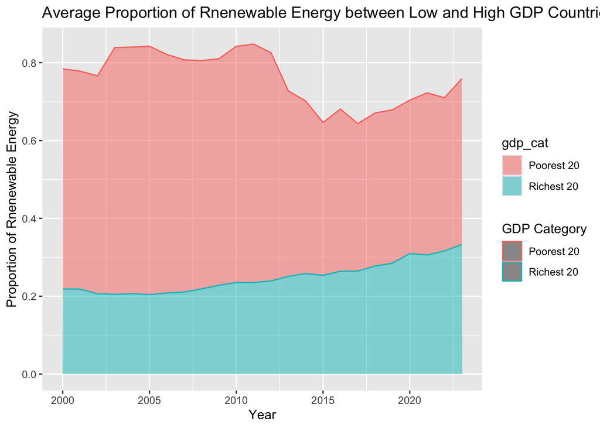

This graph shows that renewable energy actually accounts for a greater proportion of the total energy in developing low-GDP countries than in wealthy high-GDP countries. Possible explanations for this outcome:

- Low-GDP countries have more access to new renewable technologies. *(based on the dwonward slope, this is very unlikely)
- Low-GDP countries have a low amount of energy in the first place, so it is easier for the proportion of renewable energy to be higher.
- Development in these nations is occurring at the same time as these technological advancements, and thus, their energy system is built around renewable energy.
- Intentional pushes to bring developing nations’ renewable energy are successful.

## Total Amount of Renewable Energy produced by low-GDP countries vs High-Gdp Countries

#### This graph shows the total mount of renewable energy that the top 20 GDP Countries produced vs the bottom 20 GDP Countries.

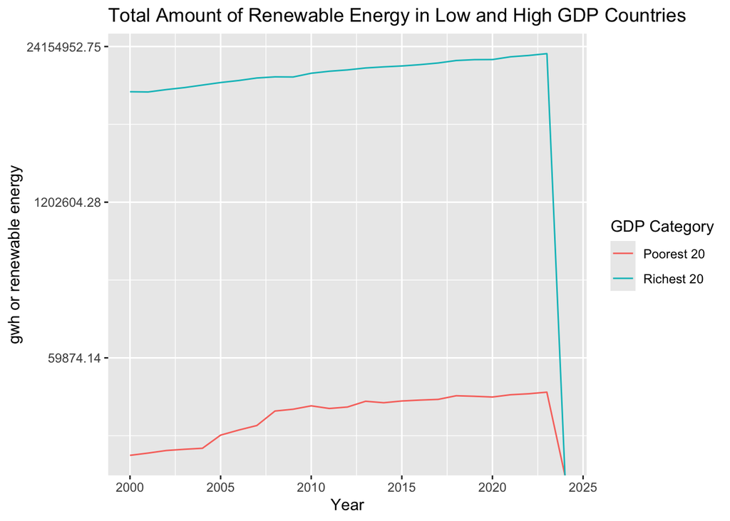

This graph shows the large discrepancy between low and high-GDP countries. We can see in this graph how much work still needs to be done to reach our sustainable development goal.

# Takeaways

Continuing forward to achieve the Sustainable Development Goals, we need to: 1. Continue to promote renewable energy in High GDP countties to increase the proportion of total energy that is renewable. 2. Make renewable energy more prevalent in low-GDP countries to both maintain a high proportion of renewable energy and increase the total amount of energy available to these low income countrues.